# Version Control - git hell

Ondřej Mottl

< — use arrow keys to navigate —>

## Half the battle

Getting all the necessary software installed, configured, and playing nicely together is honestly half the battle … **Brace yourself for some pain**

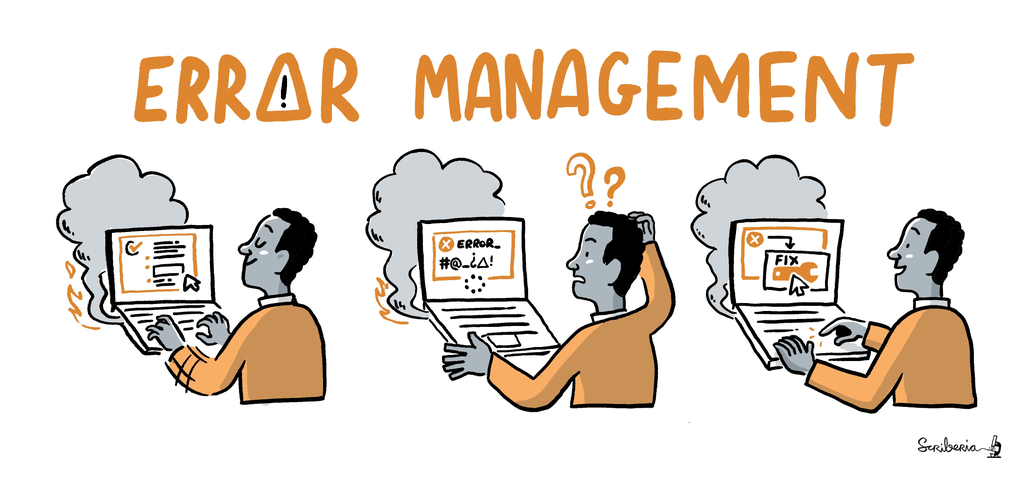

[Happy Git and GitHub for the useR](https://happygitwithr.com/install-intro) | [This image was created by Scriberia for The Turing Way community and is used under a CC-BY licence](https://zenodo.org/doi/10.5281/zenodo.3332807)

## Resources

- [Happy Git and GitHub for the useR](https://happygitwithr.com/)
- [biostats: Version control with GitHub and RStudio](https://biostats-r.github.io/biostats/github/1_Git_Tutorial.html)
- [Building RAP with R: Version control with Git](https://raps-with-r.dev/git.html)
- [{usethis} tutorial](https://usethis.r-lib.org/articles/usethis-setup.html#install-git)
- [RStudio Git](https://docs.posit.co/ide/user/ide/guide/tools/version-control.html)
- [GitHub Desktop](https://docs.github.com/en/desktop)
- [Visual Studio Code](https://code.visualstudio.com/docs/editor/versioncontrol)
- [Git](https://git-scm.com/doc)
- - … and many others

## Software for version control

### Git

[figure not shown]

### GitHub

[figure not shown]

- local software
- keep track of changes of files
- you need to install it!
- host server (store the data)
- project management, collaboration, publishing
- you need an account!

## GitHub

## Making the account

You will need a GitHub account.

It is super easy to create one, just go to [GitHub.com](https://github.com/) and follow the instructions.

### Some tips

- Use a professional username, preferably your name
- Use university/science institute email address
  - You can gain acces to [GitHub Education](https://education.github.com/), e.g.free private repositories!

## Git

## 🐚 shell intermezzo

You will need to use the shell (command line) to interact with Git.

The actuall tool might differ based on your operating system.

Please refer to [this document](https://happygitwithr.com/shell) for more information.

As most users will be on Windows, we will focus on Command Prompt here. You can can open it by typing `cmd` in the Windows search bar.

## Installation

Is Git already installed?

Open Command Prompt and check your version:

```bash
git --version
## git version 2.42.0.windows.2
```

## Installation

You can click on the tabs below to see installation instructions for your operating system.

- Windows
- MacOS
- Linux

Download and install [Git for Windows](https://gitforwindows.org/)

Download and install [Git for MacOS](https://git-scm.com/download/mac)

Ubuntu or Debian Linux:

```bash
sudo apt-get install git
```

Fedora or RedHat Linux:

```bash
sudo yum install git
```

## Configuration

Introduce yourself to Git 👋

❗Note to substitute your name and the email address❗

Use the same email address as the one you used for GitHub account.

```bash
git config --global user.name "Jane Doe"
git config --global user.email "jane@example.com"
git config --global --list
```

## Git GUI client

## Choose your weapon

GUI = **G**raphical **U**ser **I**nterface

The next sections of the presentation will expain setup of each of these GUI clients. You only need to choose one!

There are many options, some of the most popular are:

[figure not shown]

### [RStudio](https://rstudio.com/)

[figure not shown]

### [GitHub Desktop](https://desktop.github.com/)

[figure not shown]

### [Visual Studio Code](https://code.visualstudio.com/)

Navigate to the slides for your chosen GUI client!

# RStudio

## RStudio IDE

[figure not shown]

[wiki](https://en.wikipedia.org/wiki/RStudio)

## Instal/update R

Make sure you have the latest version of R installed. You can check the version by running the following code in R Console:

```r
R.version.string
```

[output not shown]

Install the newest version of R from [CRAN](https://cran.r-project.org/).

[figure not shown]

### Bonus

Check out [{updateR}](https://www.danieldsjoberg.com/updater/) package to update R and all installed packages.

## Install/update RStudio

Make sure you have the latest version of RStudio installed. You can check the version by running:

```r
rstudioapi::versionInfo()$version
```

You can download the newest version of RStudio from [RStudio website](https://rstudio.com/products/rstudio/download/).

[figure not shown]

## {usethis} package

The [{usethis} package](https://usethis.r-lib.org/index.html) is a collection of functions that help automate package and project setup tasks.

Install the package by running:

```r
install.packages("usethis")
```

[figure not shown]

## RStudio Projects

**R-studio** is using Projects, which are a way to organize your work in RStudio.

You can create a new project by going to `File` -> `New Project...` and following the instructions.

[figure not shown]

[Reproducible Data Science](https://ecorepsci.github.io/reproducible-science/index.html)

## Can you hear me now?

We now need to make sure that **RStudio** can communicate with **Git**.

### Step 1 - Git

You need to activate Git for your RStudio Project by running:

```r
usethis::use_git()
```

If needed, set the name and email by running (replace with your name and email):

```r
# replace with your name and email
usethis::use_git_config(user.name = "Jane Doe", user.email = "jane@example.com")
```

## Can you hear me now?

We now need to make sure that **RStudio** can communicate with **GitHub**.

### Step 2 - PAT (Personal Access Token)

You can check more details about it here and [here](https://happygitwithr.com/https-pat#https-pat).

```r
usethis::create_github_token()
```

Click Generate token and copy the token to a safe place.

## Can you hear me now?

Add the PAT to RStudio by running:

### Step 3 - RStudio3

```r
gitcreds::gitcreds_set()
```

You will be prompted to enter the PAT you generated in the previous step (“**Replace these credentials**” option).

## Can you hear me now?

Other useful functions to check if everything is set up correctly:

```r
# Read about PAT
usethis::gh_token_help()

# List all git settings
usethis::git_sitrep()

# Check if PAT is set
gh::gh_whoami()
```

# GitHub Desktop

## GitHub Desktop

[figure not shown]

[GitHub Desktop](https://github.com/apps/desktop)

## Installation

Dowload and install [GitHub Desktop](https://docs.github.com/en/desktop/installing-and-authenticating-to-github-desktop/installing-github-desktop).

There is an option to install for all Operating Systems (Windows, Linux, MacOS).

## Configuration

Link your GitHub account to GitHub Desktop.

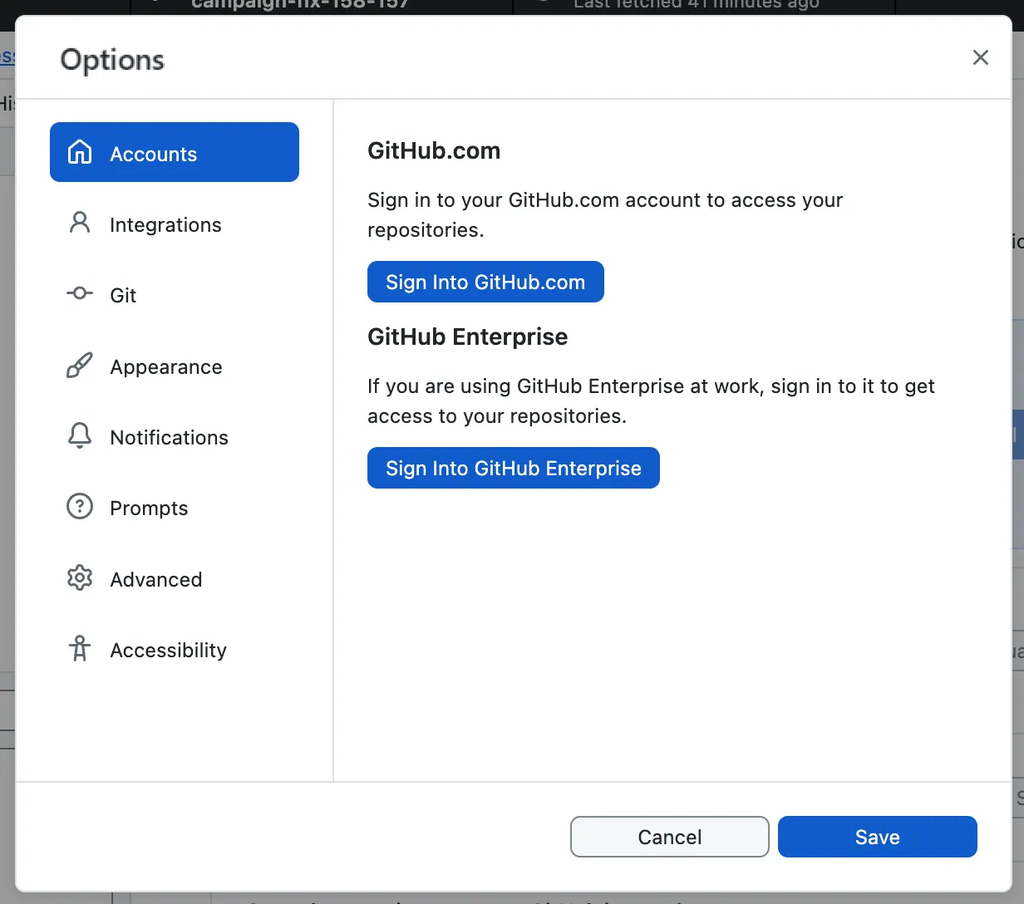

[Getting started with GitHub Desktop](https://docs.github.com/en/desktop/overview/getting-started-with-github-desktop)

# Visual Studio Code

## Visual Studio Code

[figure not shown]

[Visual Studio Code](https://code.visualstudio.com/)

## Installation

Download and install [Visual Studio Code](https://code.visualstudio.com/Download).

There is an option to install for all Operating Systems (Windows, Linux, MacOS).

## GitHub integration

Install the [GitHub Pull Requests and Issues](https://marketplace.visualstudio.com/items?itemName=GitHub.vscode-pull-request-github) extension.

Link your GitHub account to Visual Studio Code.

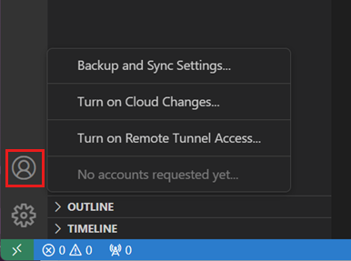

[GitHub integration in Visual Studio Code](https://code.visualstudio.com/docs/editor/versioncontrol)

# Outro

## About me

[figure not shown]

[figure not shown]

Ondřej Mottl Assistant Professor at [Charles University](https://cuni.cz/UK-1.html)

- 📧 Ondrej.mottl(at)gmail.com
- 🐦 [@OndrejMottl](https://twitter.com/OndrejMottl)
- 🐱 [Github](https://github.com/OndrejMottl)
- 🆔 [ORCID](https://orcid.org/0000-0002-9796-5081)
- 🌐 [Personal webpage](https://ondrejmottl.github.io/)
- 🧑‍💻 [Laboratory of Quantitative Ecology](https://ondrejmottl.github.io/lab/about_the_lab.html)

## This presentation

[😸 Code on GitHub](https://github.com/OndrejMottl/VersionControl_gitHell)

[🖥️ Slides](https://ondrejmottl.github.io/VersionControl_gitHell/)